# HarvardX Data Science Program

Credit Card Fraud Detection project

Do Quang Anh

2022-04-08

# Introduction

Billions of dollars of loss are caused every year due to fraudulent credit card transactions. The design of efficient fraud detection algorithms is key to reducing these losses, and more algorithms rely on advanced machine learning techniques to assist fraud investigators. The design of fraud detection algorithms is however particularly challenging due to non-stationary distribution of the data, highly imbalanced classes distributions and continuous streams of transactions. At the same time public data are scarcely available for confidentiality issues, leaving unanswered many questions about which is the best strategy to handle this issue.

## About Dataset

The dataset contains transactions made by credit cards in September 2013 by European cardholders.This dataset from Kaggle is available here: https://www.kaggle.com/datasets/mlg-ulb/creditcardfraud. This dataset presents transactions that occurred in two days, where have 492 frauds out of 284,807 transactions. The dataset is highly unbalanced, the positive class (frauds) account for 0.172% of all transactions.

It contains only numerical input variables which are the result of a PCA transformation. Unfortunately, due to confidentiality issues, features V1, V2, … V28 are the principal components obtained with PCA, the only features which have not been transformed with PCA are ‘Time’ and ‘Amount’. Feature ‘Time’ contains the seconds elapsed between each transaction and the first transaction in the dataset. The feature ‘Amount’ is the transaction Amount, this feature can be used for example-dependant cost-sensitive learning. Feature ‘Class’ is the response variable and it takes value 1 in case of fraud and 0 otherwise.

# Exploratory data analysis and data cleaning

| Dataset | Number of Rows | Number of Columns |
| --- | --- | --- |
| Credit card | 284,807 | 31 |

All the features, apart from “time” and “amount” are anonymised. Let’s see whether there is any missing data.

|  | x |
| --- | --- |
| Time | 0 |
| V1 | 0 |
| V2 | 0 |
| V3 | 0 |
| V4 | 0 |
| V5 | 0 |
| V6 | 0 |
| V7 | 0 |
| V8 | 0 |
| V9 | 0 |
| V10 | 0 |
| V11 | 0 |
| V12 | 0 |
| V13 | 0 |
| V14 | 0 |
| V15 | 0 |
| V16 | 0 |
| V17 | 0 |
| V18 | 0 |
| V19 | 0 |
| V20 | 0 |
| V21 | 0 |
| V22 | 0 |
| V23 | 0 |
| V24 | 0 |
| V25 | 0 |
| V26 | 0 |
| V27 | 0 |
| V28 | 0 |
| Amount | 0 |
| Class | 0 |

There are no NA values in the data.

## Check for class imbalance

Unbalanced data refers to unequal instances of different classes. The visualization shown below further reflects the imbalance of non-fraud and fraud transactions in the dataset. We have class (0 — No fraud, 1 — fraud) on the X-axis and the percentage of instances plotted on Y-axis. We see that our dataset is highly unbalanced with respect to the class of interest(Fraud).

| Class | Count |
| --- | --- |
| 0 | 284,315 |
| 1 | 492 |

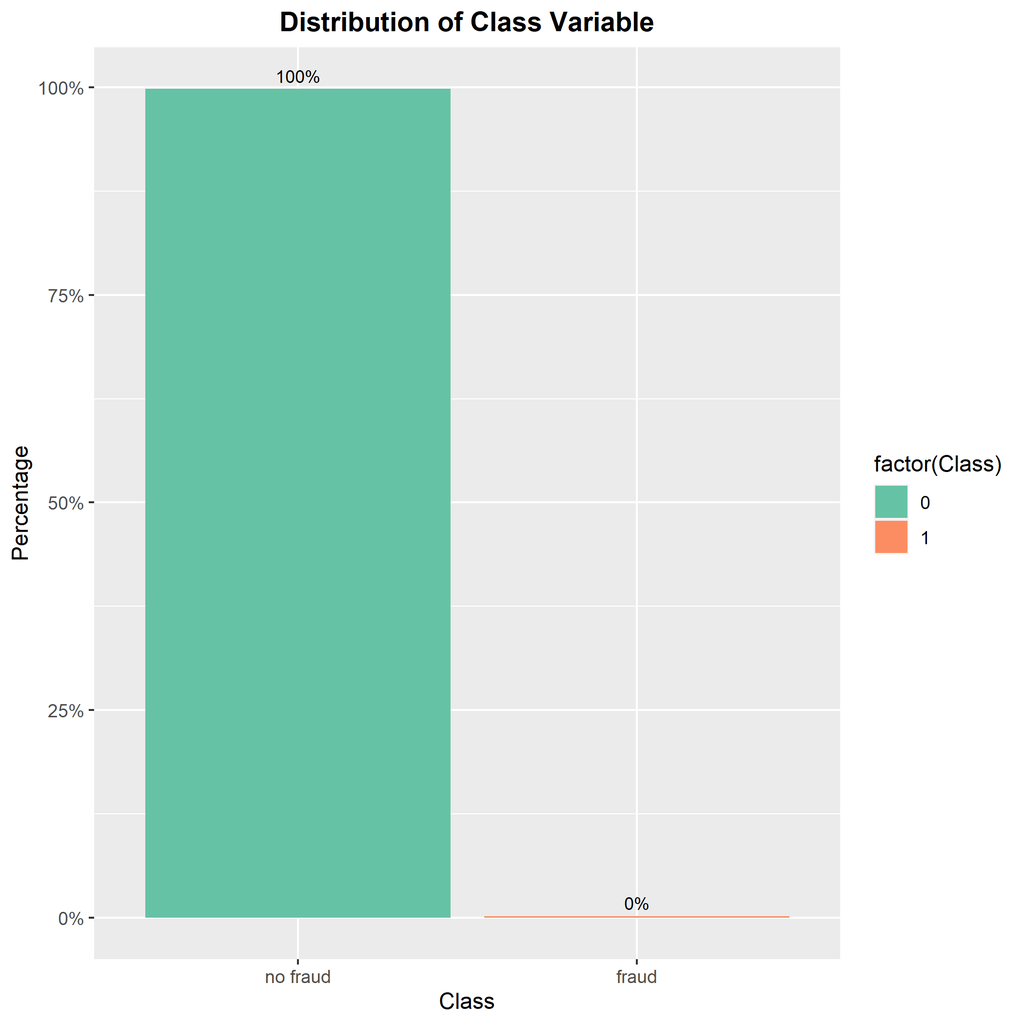

## Time variable - Frauds over Time Distribution

In the graph below, notice that the number of regular transactions drops sharply around the 90,000th-second mark, to surge again around the 110,000th-second mark. It wouldn’t be absurd to assume that this period is during the night when individuals naturally perform fewer purchases and transactions than during the daytime.

On the other hand, a great number of fraudulent transactions occurred around the 100,000 mark, which could confirm the previous assumption, considering that criminals should prefer to commit fraud late at night, assuming there would be less surveillance and victims would not realize they were being scammed soon enough.

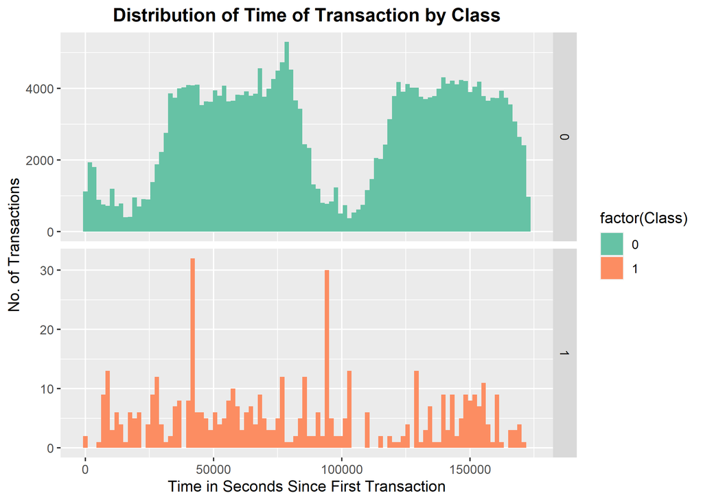

```r
df %>%
  ggplot(aes(x = Time, fill = factor(Class))) + geom_histogram(bins = 100)+
  labs(x = 'Time in Seconds Since First Transaction', y = 'No. of Transactions') +
  ggtitle('Distribution of Time of Transaction by Class') +
  scale_fill_brewer(palette = "Set2") +
  facet_grid(Class ~ ., scales = 'free_y') + common_theme
```

## Amount Variable

The boxplot below demonstrates the Amount of each transaction is more variable with the non-fraud transactions than with the fraud transactions given the number of outliers. Most transactions, both regular and fraudulent, were of “small” values. Small amount of money, less or equal of one dollar are scammed more frequently.

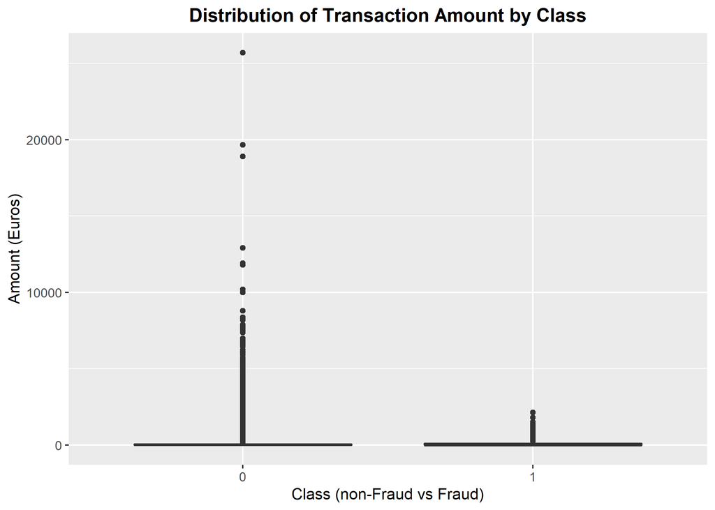

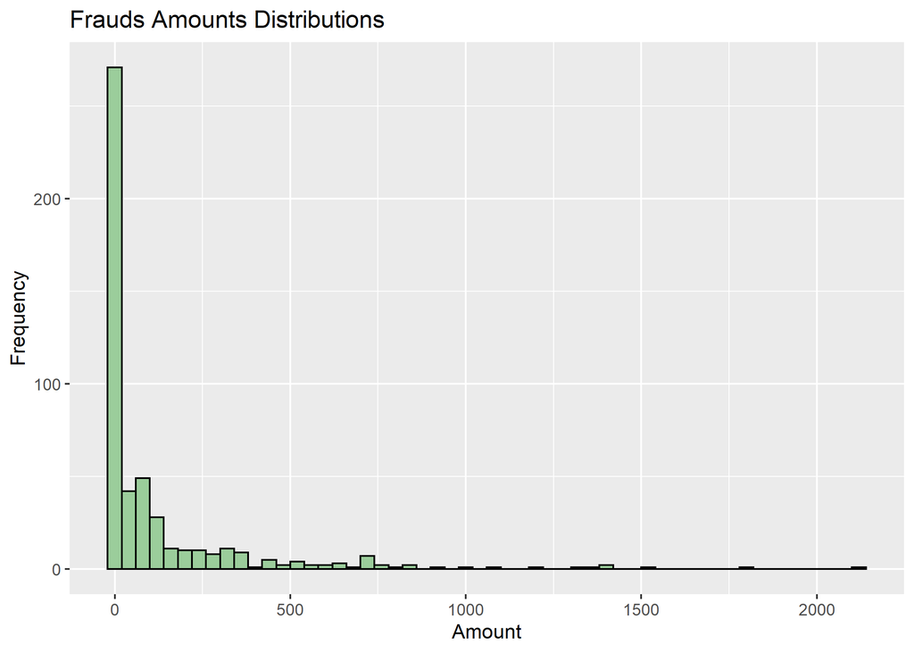

## Correlations between each variables

```
##         Time    V1    V2    V3    V4    V5    V6    V7    V8    V9   V10   V11
## Time    1.00  0.19 -0.01 -0.47 -0.14  0.23 -0.11  0.12 -0.10  0.02  0.01 -0.23
## V1      0.19  1.00 -0.38 -0.41  0.10 -0.11 -0.09 -0.23 -0.24  0.14  0.23  0.01
## V2     -0.01 -0.38  1.00  0.07  0.16  0.34 -0.11  0.43  0.01 -0.08 -0.21 -0.01
## V3     -0.47 -0.41  0.07  1.00  0.06 -0.22  0.17 -0.07  0.16 -0.03 -0.07  0.06
## V4     -0.14  0.10  0.16  0.06  1.00  0.02  0.08  0.06 -0.01  0.11  0.03 -0.01
## V5      0.23 -0.11  0.34 -0.22  0.02  1.00 -0.01  0.43 -0.06 -0.06 -0.15  0.01
## V6     -0.11 -0.09 -0.11  0.17  0.08 -0.01  1.00 -0.29  0.44  0.03  0.06  0.06
## V7      0.12 -0.23  0.43 -0.07  0.06  0.43 -0.29  1.00 -0.39 -0.10 -0.21  0.00
## V8     -0.10 -0.24  0.01  0.16 -0.01 -0.06  0.44 -0.39  1.00  0.00 -0.12  0.05
## V9      0.02  0.14 -0.08 -0.03  0.11 -0.06  0.03 -0.10  0.00  1.00 -0.29 -0.03
## V10     0.01  0.23 -0.21 -0.07  0.03 -0.15  0.06 -0.21 -0.12 -0.29  1.00  0.03
## V11    -0.23  0.01 -0.01  0.06 -0.01  0.01  0.06  0.00  0.05 -0.03  0.03  1.00
## V12     0.07  0.00  0.05 -0.05  0.15 -0.05  0.04 -0.04  0.11  0.10 -0.16  0.20
## V13    -0.05  0.05  0.03  0.01 -0.02  0.02  0.00 -0.02 -0.14 -0.05  0.00 -0.04
## V14    -0.09 -0.02  0.09 -0.13  0.10  0.04 -0.07  0.06  0.04 -0.03  0.00  0.15
## V15    -0.21  0.03  0.04  0.05  0.05 -0.04 -0.05 -0.05 -0.02  0.00 -0.03 -0.04
## V16     0.00  0.04  0.07 -0.05 -0.04 -0.01 -0.02 -0.12  0.09 -0.03 -0.06  0.07
## V17    -0.10 -0.06  0.00 -0.04  0.05 -0.15 -0.03 -0.15  0.07 -0.07 -0.15  0.07
## V18     0.09 -0.04  0.01 -0.05  0.02 -0.02  0.05 -0.07  0.07 -0.01 -0.05  0.07
## V19     0.03  0.03  0.00 -0.02 -0.02  0.01  0.03  0.00 -0.03  0.00  0.04  0.01
## V20    -0.12 -0.21  0.04  0.11 -0.01  0.06  0.05  0.16  0.01 -0.02 -0.09  0.04
## V21     0.10 -0.06 -0.10 -0.04  0.04 -0.04  0.03 -0.02  0.08 -0.07 -0.05  0.00
## V22     0.13 -0.03 -0.06  0.00  0.00 -0.01  0.04 -0.02  0.02  0.00  0.04  0.00
## V23     0.15  0.15 -0.09 -0.14  0.01 -0.11 -0.05 -0.19  0.08  0.07  0.08  0.03
## V24    -0.02  0.00  0.01  0.00 -0.01 -0.02 -0.14 -0.01 -0.02  0.00 -0.01 -0.01
## V25    -0.26  0.05 -0.09  0.03  0.06 -0.02 -0.01 -0.05 -0.07 -0.02 -0.02 -0.01
## V26     0.00  0.01  0.03 -0.02 -0.06  0.03 -0.02  0.02 -0.01  0.03 -0.03 -0.01
## V27    -0.04 -0.10  0.13  0.14 -0.03  0.01  0.07 -0.09  0.19  0.00 -0.02 -0.03
## V28    -0.14 -0.21  0.14  0.18  0.00 -0.03  0.02  0.06  0.09 -0.10 -0.13 -0.03
## Amount -0.04 -0.09 -0.50  0.00 -0.02 -0.31  0.21 -0.03  0.00 -0.08  0.05 -0.04
## Class  -0.01 -0.04  0.05 -0.06  0.06 -0.03 -0.04 -0.05  0.02 -0.05 -0.06  0.06
##          V12   V13   V14   V15   V16   V17   V18   V19   V20   V21   V22   V23
## Time    0.07 -0.05 -0.09 -0.21  0.00 -0.10  0.09  0.03 -0.12  0.10  0.13  0.15
## V1      0.00  0.05 -0.02  0.03  0.04 -0.06 -0.04  0.03 -0.21 -0.06 -0.03  0.15
## V2      0.05  0.03  0.09  0.04  0.07  0.00  0.01  0.00  0.04 -0.10 -0.06 -0.09
## V3     -0.05  0.01 -0.13  0.05 -0.05 -0.04 -0.05 -0.02  0.11 -0.04  0.00 -0.14
## V4      0.15 -0.02  0.10  0.05 -0.04  0.05  0.02 -0.02 -0.01  0.04  0.00  0.01
## V5     -0.05  0.02  0.04 -0.04 -0.01 -0.15 -0.02  0.01  0.06 -0.04 -0.01 -0.11
## V6      0.04  0.00 -0.07 -0.05 -0.02 -0.03  0.05  0.03  0.05  0.03  0.04 -0.05
```

[output cut: 41 more lines]

```
## V16    -0.03 -0.02  0.04 -0.05 -0.01  -0.11 -0.05
## V17     0.05  0.00 -0.01  0.05  0.06   0.05 -0.04
## V18    -0.05 -0.01 -0.03  0.02  0.02   0.05 -0.03
## V19    -0.06  0.00 -0.02 -0.02 -0.04  -0.01  0.02
## V20     0.04  0.04  0.05  0.10  0.28   0.20  0.02
## V21     0.03  0.04 -0.04 -0.03  0.07   0.19  0.04
## V22     0.01  0.03 -0.04  0.07 -0.04   0.08  0.00
## V23     0.10 -0.43  0.00  0.05 -0.07  -0.06 -0.01
## V24     1.00  0.00  0.01 -0.04  0.05  -0.01 -0.01
## V25     0.00  1.00 -0.05 -0.09 -0.05   0.02  0.00
## V26     0.01 -0.05  1.00 -0.16 -0.02  -0.07  0.01
## V27    -0.04 -0.09 -0.16  1.00  0.46  -0.13  0.03
## V28     0.05 -0.05 -0.02  0.46  1.00   0.01  0.02
## Amount -0.01  0.02 -0.07 -0.13  0.01   1.00 -0.01
## Class  -0.01  0.00  0.01  0.03  0.02  -0.01  1.00
```

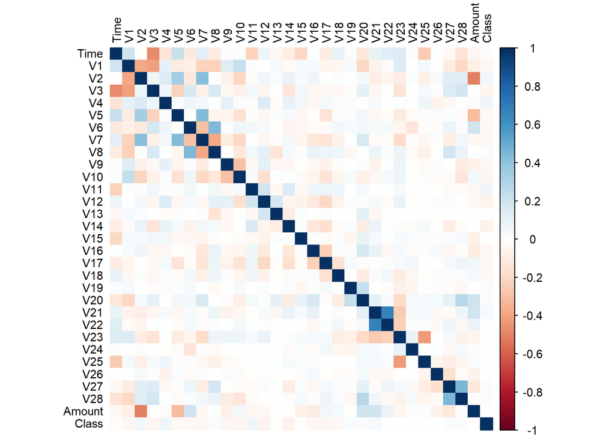

# Analysis - Models Building and Comparison

## Data Pre Processing

**1. Remove the “Time” column and Change ‘Class’ variable to factor from the dataset**

```r
# Set seed for reproducibility
set.seed(1234)
# Remove the "Time" column from the dataset
df <- df %>% select(-Time)
#Change 'Class' variable to factor
df$Class <- as.factor(df$Class)
```

**2. Split the dataset into train, test, cv dataset**

```r
# Split the dataset into train, test and cross validation dataset
train_index = createDataPartition(y = df$Class,
                                  p = .6,
                                  list = F)
train <- df[train_index,]
test_cv <-df[-train_index,]

test_index = createDataPartition(y = test_cv$Class,
                                  p = .5,
                                  list = F)

test <- test_cv[test_index,]
cv <- test_cv[-test_index,]

rm(train_index, test_index, test_cv)
```

## Classification Models

Classification is the process of predicting discrete variables (1/0, Yes/no, etc.). Given the case with our dataset, it will be more optimistic to deploy a classification model rather than any others. To better understand which algorithm would perform best on the given dataset, the following algorithms are used:Naive Bayes, KNN, Random Forest,XGBoost

### Naive Algorithm

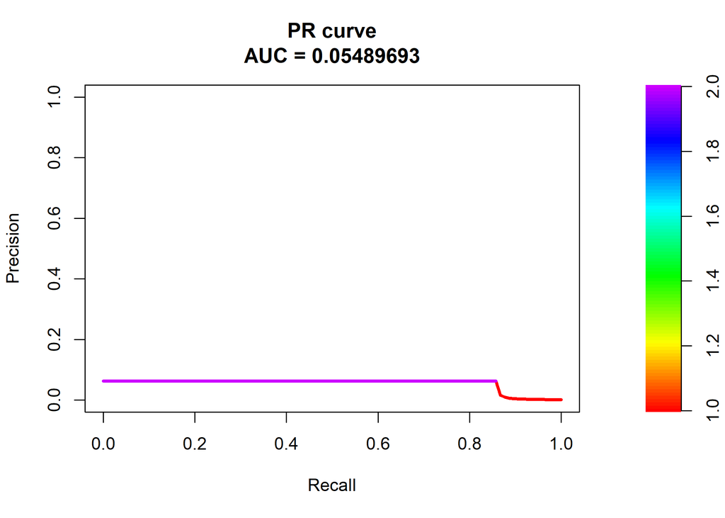

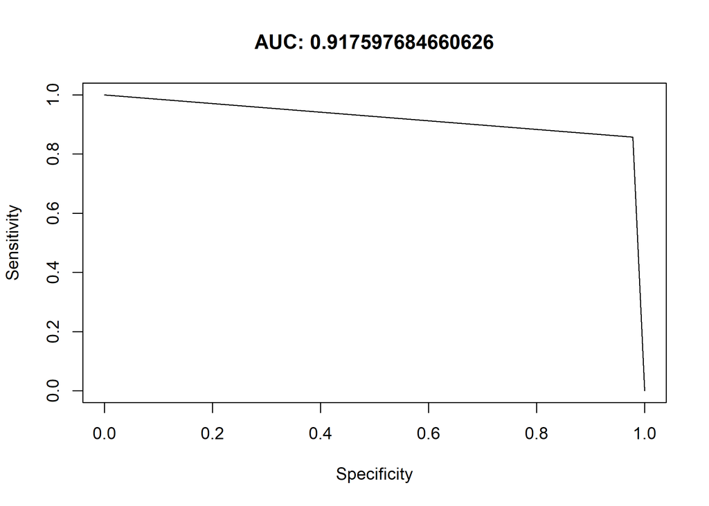

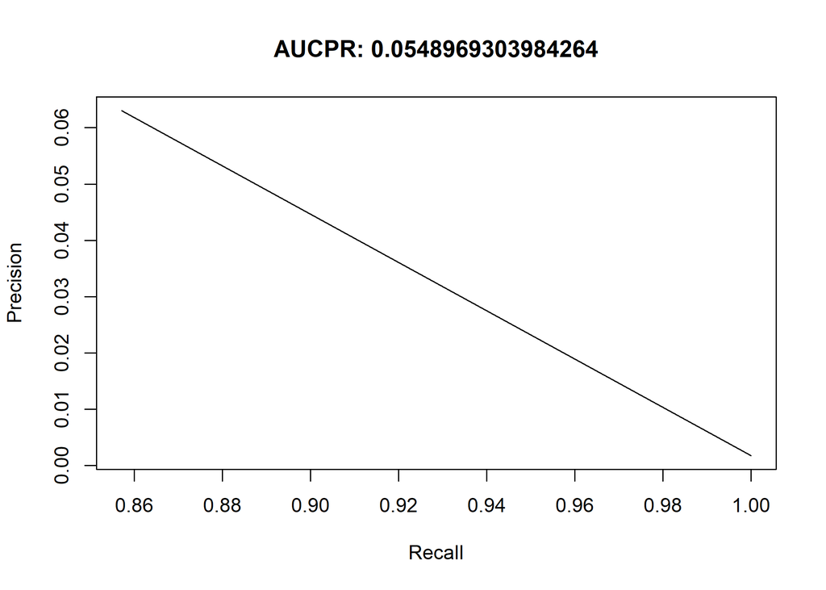

| Model | AUC | AUCPR |
| --- | --- | --- |
| Naive Bayes | 0.9175977 | 0.0548969 |

### KNN

A KNN Model with k=5 can achieve a significant improvement in respect to the previous models, as regard AUCPR of **0.58** at the expense of a little drop off AUC, that is **0.81**.

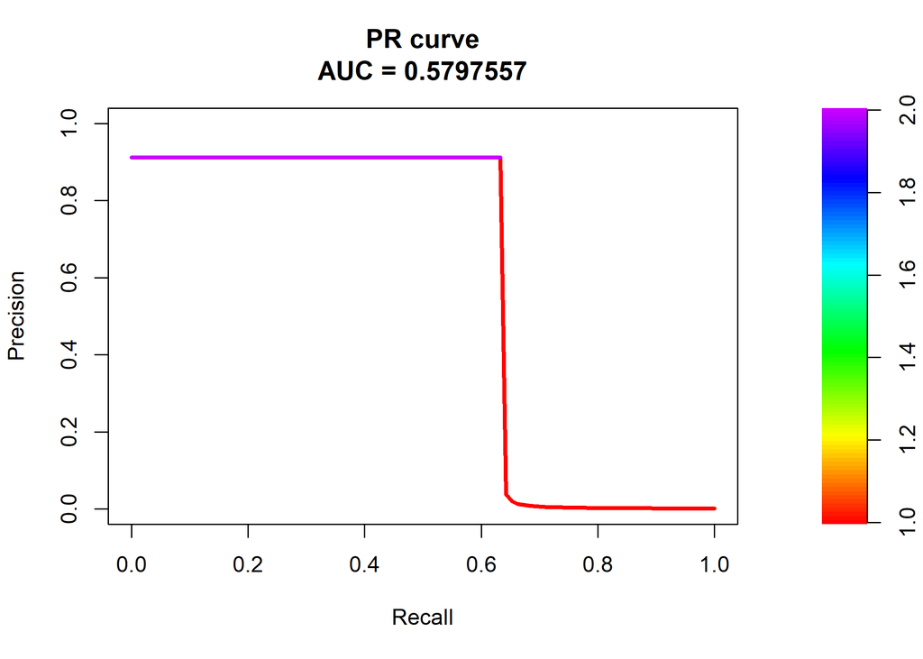

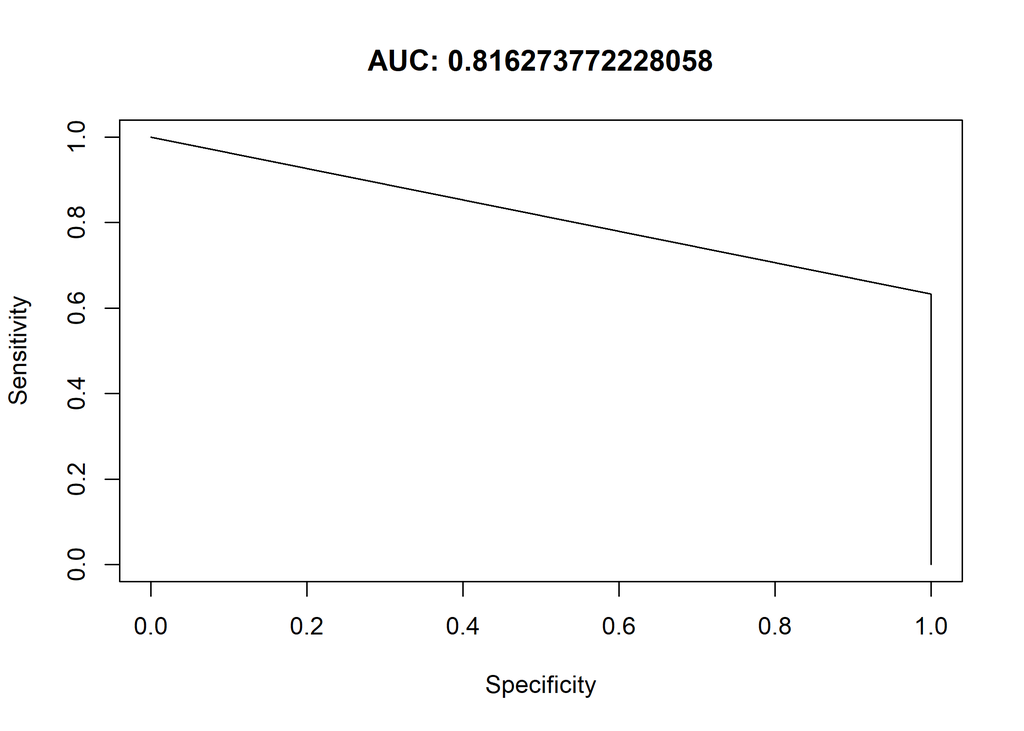

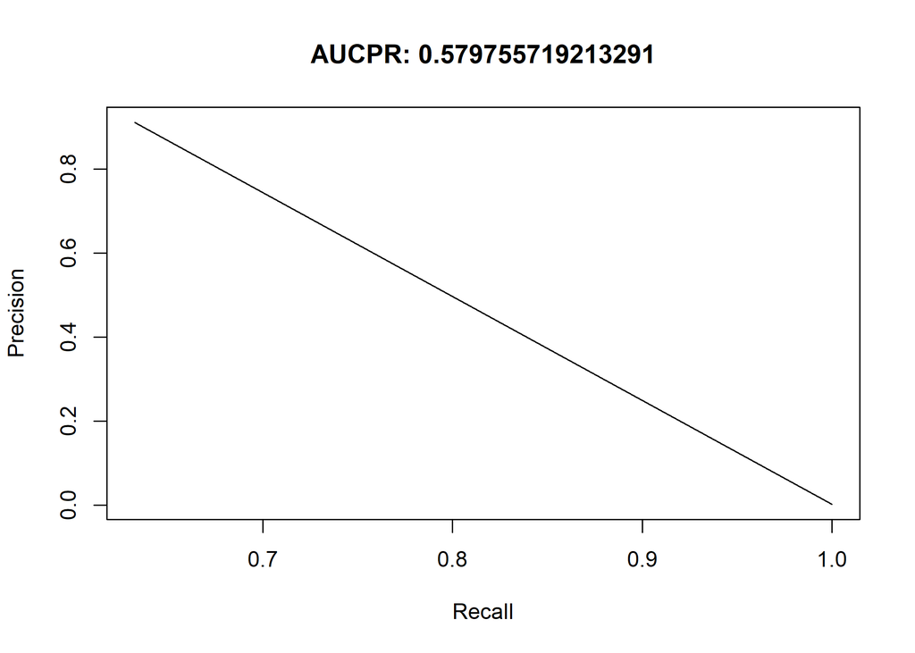

| Model | AUC | AUCPR |
| --- | --- | --- |
| Naive Bayes | 0.9175977 | 0.0548969 |
| K-Nearest Neighbors k=5 | 0.8162738 | 0.5797557 |

### Random Forest

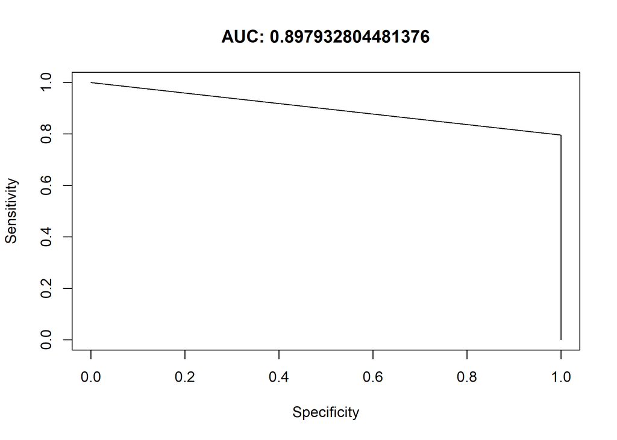

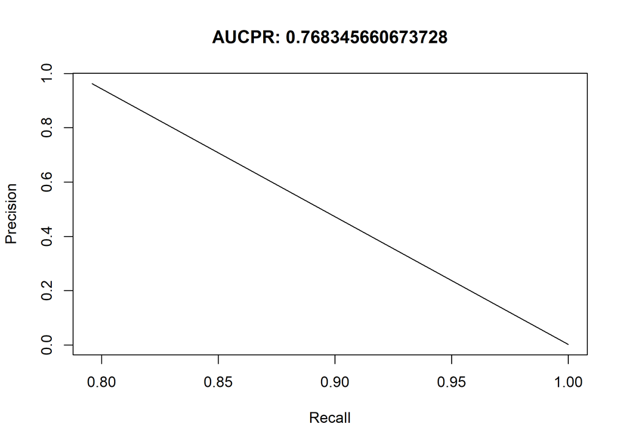

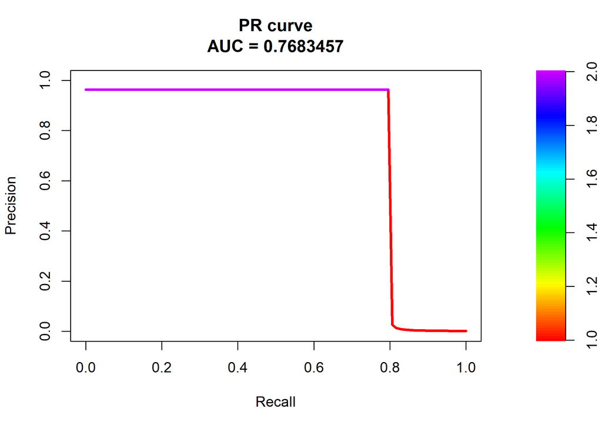

| Model | AUC | AUCPR |
| --- | --- | --- |
| Naive Bayes | 0.9175977 | 0.0548969 |
| K-Nearest Neighbors k=5 | 0.8162738 | 0.5797557 |
| Random Forest | 0.8979328 | 0.7683457 |

|  | MeanDecreaseGini |
| --- | --- |
| V1 | 8.708982 |
| V2 | 7.784292 |
| V3 | 8.985490 |
| V4 | 17.257080 |
| V5 | 7.772203 |
| V6 | 8.821890 |
| V7 | 19.072039 |
| V8 | 7.013489 |
| V9 | 23.520504 |
| V10 | 43.772484 |
| V11 | 44.997607 |
| V12 | 73.056009 |
| V13 | 6.829304 |
| V14 | 63.479173 |
| V15 | 6.388524 |
| V16 | 40.124086 |
| V17 | 105.084852 |
| V18 | 16.236771 |
| V19 | 8.041600 |
| V20 | 8.359602 |
| V21 | 10.723973 |
| V22 | 5.886333 |
| V23 | 4.705090 |
| V24 | 6.127916 |
| V25 | 5.290926 |
| V26 | 10.888757 |
| V27 | 9.216603 |
| V28 | 6.266699 |
| Amount | 7.974071 |